# 5주차 · 유사도를 수학으로 표현하기

## 컴퓨터는 0과 1 밖에 몰라요 유사도를 수학으로 표현하는 방법

2026 · 약학실험2 · WEEK 05

집합에서 유사도를 처리하던 방식의 발전을 알아보자  
하나의 개념을 컴퓨터가 이해하는 수학으로 표현하기

Fingerprint 및 Molecular descriptor를 사용하여 유사도를 계산했다. 하지만 유사도를 계산하는 공식 자체도 다양한 방식으로 정의될 수 있다.

## 이번 주 학습 목표

유사하다는 기준을 되짚어보고 그것을 수식으로 나타내보기

### ① 단일 기준의 유사도

과일 분류 작업으로 해보자

Molecular descriptor처럼, 하나의 수치로 나타나는 기준에 따라 분류하고, 유사함을 지목해본다.

### ② 다중 기준의 유사도

특징들을 집합으로 표현

집합끼리의 유사도를 어떻게 계산할 수 있을까?

### ③ 유사도(%)와 거리

거리 기반 유사도

어떻게 거리를 통해 유사도를 표현한다는 것일까?

## 과일이 가진 성질들을 숫자로 나타내보자

우리가 사용했던 Molecular descriptor와 같은 개념이다!

유사하다는 개념은 기준에 따라 달라지는 것을 우리는 배웠다. 이러한 것은 단순히 분자가 아닌, 실제 현실에서도 마찬가지다.

위와 같은 과일들을 가지고 있다고 해보자. 어떻게 유사한 그룹을 묶을 수 있을까?

## 단일 기준으로는 손쉽게 분류 작업을 진행할 수 있다

단순히 모양 뿐만 아니라 그 성질을 기준으로 우리는 유사한 그룹을 묶을 수 있다.

아래 비교 기준을 선택하여 배치를 확인해보자. 각자 일정한 기준으로 그룹을 나눌 수 있을텐데, 우리는 어떻게 이것을 직관적으로 진행할까?

## 한 과일을 단일 수치로 비교해보자

수분 함량만으로 비교

E와 수분 함량이 가장 비슷한 과일은 어떤 것일까?  
무의식적으로 우리는 E의 값과 대조하며, 차이가 작은 것을 골랐다.

## 수학적으로는 선분 위 값의 차이가 곧 거리가 되는 셈이다

수분 함량을 수직선 위에 표현해보자

숫자의 차이가 작다는 것은, 수직선 위에서 가깝다는 뜻이다.  
이를 "유사하다"는 개념과 연결하면, 거리가 가까운 것이 유사한 것이 되는 셈이다.

## 하나의 기준으로 유사한 과일을 찾기 어렵다. 여러 기준을 쓴다면?

수분 함량 + 당도로 다시 확인해보자.

A와 더 유사한 과일은 B일까, C일까?  
두 값의 차이를 각각 구해 평균을 낼까? 다른 방법으로 합칠 수도 있을까?

## 두 차이의 평균으로 비교해볼까?

수직선 위 비교를 2개의 축으로 진행해야 한다. 단순하게 진행해보자

$$D_{\text{평균}}=\frac{\Delta_{\text{수분}}+\Delta_{\text{당도}}}{2}$$

이 규칙에서는 두 후보가 모두 2.5로 동일한 수치를 나타내고 있다.  
이 수치를 다시, **좌표**로 읽으면 어떤 모습일까?

## 반가워요 XY 좌표계! 숫자는 모두 좌표계 위에 표현할 수 있다

수분함량을 X축으로, 당도를 Y축으로 표현하면 좌표로 만들 수 있다!

[figure not shown]

$$D_{\text{평균}}=\frac{\Delta_{\text{수분}}+\Delta_{\text{당도}}}{2}$$

이 수식으로는 A와 B, C 사이에 어떤 것이 더 유사한지 알 수가 없다. 이게 정말 최선일까?

## 선분 위 거리로 유사도를 표현했었으니, 좌표계에서도 거리를 쓴다면?

5칸 씩 움직였던 친구가 이제는 좀 달라보인다.

[figure not shown]

### 직선거리로 확인하는 방법. 이걸 Euclidean distance라고 한다.

### A ↔︎ B

$$|\overline{AB}|=\sqrt{2^2+3^2}=\sqrt{13}\approx 3.61$$

### A ↔︎ C

$$|\overline{AC}|=\sqrt{4^2+1^2}=\sqrt{17}\approx 4.12$$

**이 규칙에서는 거리가 작은 B가 A에 더 가깝다.**

## 특징이 많아져도 점과 점 사이의 거리로 계산한다

수분 함량 = X축 · 당도 = Y축 · 씨앗/과육 비율 = Z축 · 특징이 수백 개라면?

[figure not shown]

각 특징이 하나의 축이 되고,  
과일 하나가 XYZ 공간의 점 하나가 된다.

$$d(A,B)=\sqrt{(x_A-x_B)^2+(y_A-y_B)^2+(z_A-z_B)^2}$$

Feature가 $n$개라면 $d(A,B)=\sqrt{(a_1-b_1)^2+(a_2-b_2)^2+\cdots+(a_n-b_n)^2}$로 쓴다. $a_i$와 $b_i$는 각각 A와 B의 $i$번째 Feature의 값이다. 네 축 이상을 그림으로 그리지 않아도 같은 방식으로 계산할 수 있다!

## 잠깐, 거리가 곧 유사도라니? 유사도(%)가 아니라 숫자의 크기일 뿐인 것 같은데요?

유사도는 정도의 표현이다. %로 나타낼 수도 있지만, 숫자 차이로도 나타낼 수 있다.  
가까움을 표현하는 두 가지 방식을 비교해보자

### 거리로 표현하기

거리가 얼마나 떨어져 있는가?

3.61

작을수록 가깝다. 같은 점이면 0.

단순한 직선 거리를 계산하는 Euclidean distance에는 고정된 최댓값이 없다!

### 퍼센트로 표현하기

모든 것은 상대적이므로 퍼센트로 표현할지 말지는 내 마음대로다.

80%

1(100%)에 가까울 수록 같다.

0–1 범위의 점수라면 0–100%로 표시할 수 있다.

중요한 것은 Euclidean distance도 퍼센트로 나타내는 것은 충분히 가능하다는 것이다.  
주어진 데이터 리스트에서 모든 거리를 계산한 뒤, 최대값으로 모든 값을 나누면 0–100% 범위의 퍼센트로 나타낼 수 있다.

## 좌표계를 쓰는 건 알겠는데요, 거리 기반 밖에 없나요?

Cosine similarity가 있다! 원점에서 뻗어나가는 두 벡터의 사이각으로 유사도를 나타낸다!

[figure not shown]

### Cosine similarity = cos θ

$$S_{\cos}(\mathbf{p},\mathbf{q})=\cos\theta
=\frac{\mathbf{p}\cdot\mathbf{q}}{\|\mathbf{p}\|\,\|\mathbf{q}\|}$$

두 벡터의 **내적**을 **각 벡터 길이의 곱**으로 나눈다.

### p = (1, 2), q = (2, 1)

$$S_{\cos}=\frac{1\times2+2\times1}{\sqrt{5}\times\sqrt{5}}
=\frac45=0.8$$

### p랑 r이랑 비교하면?

$\cos\theta$에서는 다른 건 고려하지 않고 각도만을 본다.  
$\theta=0^\circ$이므로 $\cos\theta=1$이다.

참고로 $\theta=90^\circ$이면 $\cos\theta=0$이다.

## 그렇다면 0과 1로 된 fingerprint도 좌표로 놓고 비교할 수 있을까?

수치형 벡터를 XY 좌표로 놓고, 점 사이의 거리와 벡터 사이의 각도로 유사도를 비교했다.

[figure not shown]

0과 1도 숫자다. 그렇다면 fingerprint도 좌표로 놓고,  
점 사이의 거리나 cosine similarity로 비교해도 될까?

## 가능하다! 2048 bit라면 2048차원의 좌표다

같은 방식으로 만든 fingerprint에서 같은 위치의 bit를 하나의 좌표로 나타낼 수 있다

### Bit도 좌표로 나타낼 수 있다! 벡터가 그 뜻이니까!

(1, 0) → 2차원  
(1, 0, 1, …, 0) → 2048차원

2048개 축을 그릴 수 없어도,  
각 성분끼리 계산하면 된다.

### 0,1도 숫자이므로 계산할 수 있다

Euclidean distance: 더 이상 거리가 아닌, 서로 다른 bit를 세는 것이 된다.  
Cosine similarity: 두 벡터의 방향이 얼마나 같은가?

Cosine 식은 두 벡터의 길이가 0보다 클 때 쓴다.

$$d(\mathbf{x},\mathbf{y})=\sqrt{\sum_{i=1}^{n}(x_i-y_i)^2},\qquad
S_{\cos}=\frac{\sum_{i=1}^{n}x_iy_i}{\sqrt{\sum_{i=1}^{n}x_i^2}\sqrt{\sum_{i=1}^{n}y_i^2}}$$

n은 bit 수다. 계산은 가능하다. 그런데 대체 어떤 걸 쓰면 된다는 말인가!

## Fingerprint에 대해서 어떤 지표를 써야 좋은지는 이미 누군가 분석했다

8개의 서로 다른 지표를 확인했다! 인용 수 1685회의 레전드 논문이다.

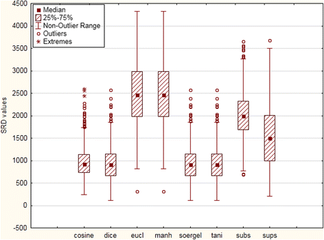

### Euclidean distance · Manhattan distance

종합 결과와 꽤 다른 순서로 분자를 정렬시켜서 변동폭이 크다고 이해하면 된다.

### Cosine · Tanimoto · Dice · Soergel

종합 결과와 더 비슷한 순서로 분자를 정렬시킨, 바람직한 지표들이다. 익숙한 Tanimoto도 이 그룹에 있다.

거리와 cosine은 모두 계산할 수 있다. 하지만 지표마다 분자의 검색 순위가 달라진다.  
Cosine도 좋은 선택이긴 하지만 Tanimoto는 대체 뭘까? 이제 Tanimoto가 무엇을 어떻게 계산하는지 알아보자.

Figure 4 원본 재사용 · Bajusz, Rácz & Héberger, *J. Cheminform.* 7, 20 (2015). [논문·그림](https://link.springer.com/article/10.1186/s13321-015-0069-3/figures/4) · [CC BY 4.0](https://creativecommons.org/licenses/by/4.0/). 여러 지표를 종합한 순서와의 비교이며, 활성 예측 정확도를 평가한 결과는 아니다.

## 꽃을 특징의 집합으로 나타내보자

0,1로 표현했던 Fingerprint처럼 조건을 적용해 얻은 특징 집합을 F(A), F(B)로 나타낼 수 있다

[figure not shown]

꽃 A와 B가 함께 가진 특징이나 한 쪽에만 존재하는 특징을 비교해서 유사도를 계산한다면 어떻게 할 수 있을까?  
F(A) 및 F(B) 사이의 유사도는 계산할 수 있을까?

## 벤다이어그램으로 그려서 수학적으로 접근해보자

Fingerprint 처럼, 각각의 요소를 1과 0으로 표현할 수 있다

[figure not shown]

$$|F(A)\cap F(B)|=3$$
$$\qquad |F(A)\cup F(B)|=|F(A)|+|F(B)|-|F(A)\cap F(B)|=4+4-3=5$$

## 이것이 바로 기본적인 Tanimoto 공식이다

$$T(A,B)=\frac{|F(A)\cap F(B)|}{|F(A)\cup F(B)|}=\frac{c}{a+b-c}$$

$$T(A,B)=\frac{3}{4+4-3}=\frac35=0.6$$

두 대상 중 하나라도 가진 특징을 기준으로, 함께 가진 특징의 비율을 계산한다. 이걸 유사도라고 부르는거다.

a = F(A)의 특징 수, b = F(B)의 특징 수, c = F(A)와 F(B)의 공통 특징 수

## 다시, 집합을 0과 1로 바꿔보자

같은 다섯 조건을 0과 1로 표현하고, 꽃을 바꾸며 a,b,c가 어떻게 달라지는지 보자

## 그래서, 집합 개념은 알겠는데 이걸 수학으로 어떻게 표현하죠?

먼저, XY 좌표 위의 간단한 예로 벡터의 덧셈과 내적을 떠올려보자

[figure not shown]

여기를 이해하기 위해서 벡터의 개념과, 벡터를 곱하고 더하는 연산을 써야 한다. 벡터의 내적을 떠올려야 한다!

## 벡터의 덧셈과 내적이 바로 요소별 연산이었다!

벡터의 내적이 이런 곳에 쓰는거에요?

다섯 특징들을 **정해진 순서로 나열한 벡터**로 나타냈었다.

$$\mathbf{x}=(1,1,1,0,1),\qquad \mathbf{y}=(1,0,1,1,1)$$

### 덧셈: 같은 위치끼리 더한다

$$\mathbf{x}+\mathbf{y}=(1+1,\;1+0,\;1+1,\;0+1,\;1+1)$$

$$\mathbf{x}+\mathbf{y}=(2,1,2,1,2)$$

이런 결과를 내지만 사실 우리의 집합을 수학으로 표현하는 것에는 쓸 이유가 없긴 하다.

### 내적: 같은 위치끼리 곱한 뒤 더한다

$$\mathbf{x}\cdot\mathbf{y}=1\times1+1\times0+1\times1+0\times1+1\times1$$

$$\mathbf{x}\cdot\mathbf{y}=1+0+1+0+1=3$$

이것이다! 위치별로 곱한 뒤 더하면 공통된 특징만이 살아남는다!

이 내적 연산은 Numpy의 np.dot 함수를 사용하여 계산할 수 있다.

## 자기 자신과 내적하면 각 집합의 특징 수가 된다

c는 서로의 내적, a와 b는 각 벡터의 자기 자신을 내적하는 것으로 계산한다

### 꽃 A의 특징 수 a

$$\mathbf{x}\cdot\mathbf{x}=1\times1+1\times1+1\times1+0\times0+1\times1$$

$$\mathbf{x}\cdot\mathbf{x}=1^2+1^2+1^2+0^2+1^2=4=a$$

### 꽃 B의 특징 수 b

$$\mathbf{y}\cdot\mathbf{y}=1\times1+0\times0+1\times1+1\times1+1\times1$$

$$\mathbf{y}\cdot\mathbf{y}=1^2+0^2+1^2+1^2+1^2=4=b$$

0² = 0, 1² = 1이므로, 각 값을 제곱해 더해도 1의 개수와 같다.  
따라서 자기자신을 내적하는 것은 각 집합이 가진 특징의 수가 된다.

## 정리해서 집합을 수식으로 나타내자면

| 집합에서 쓰던 항 | 벡터의 내적으로 같은 값 계산 |
| --- | --- |
| $a=\lvert F(A)\rvert=4$ | $\mathbf{x}\cdot\mathbf{x}=4$ |
| $b=\lvert F(B)\rvert=4$ | $\mathbf{y}\cdot\mathbf{y}=4$ |
| $c=\lvert F(A)\cap F(B)\rvert=3$ | $\mathbf{x}\cdot\mathbf{y}=3$ |
| $a+b-c=\lvert F(A)\cup F(B)\rvert=5$ | $\mathbf{x}\cdot\mathbf{x}+\mathbf{y}\cdot\mathbf{y}-\mathbf{x}\cdot\mathbf{y}=5$ |

$$T(A,B)=\frac{|F(A)\cap F(B)|}{|F(A)\cup F(B)|}
=\frac{\mathbf{x}\cdot\mathbf{y}}{\mathbf{x}\cdot\mathbf{x}+\mathbf{y}\cdot\mathbf{y}-\mathbf{x}\cdot\mathbf{y}}
=\frac{3}{4+4-3}=0.6$$

## 같은 내적을 NumPy의 np.dot으로 계산한다

벡터를 NumPy의 1차원 배열로 쓰면, np.dot이 같은 위치의 곱을 더해준다

```python
import numpy as np

x = np.array([1, 1, 1, 0, 1], dtype=int)  # 집합 A
y = np.array([1, 0, 1, 1, 1], dtype=int)  # 집합 B

a = np.dot(x, x)  # 4: 집합 A의 특징 수
b = np.dot(y, y)  # 4: 집합 B의 특징 수
c = np.dot(x, y)  # 3: 공통 특징 수

tanimoto = c / (a + b - c)
print(tanimoto)   # 0.6
```

x * y는 각 위치의 곱을 담은 벡터, np.dot(x, y)는 그 곱을 모두 더한 숫자다.

[NumPy 공식 문서 · 1차원 배열 두 개의 np.dot은 벡터의 내적](https://numpy.org/doc/stable/reference/generated/numpy.dot.html)

## 같은 방식으로, Tanimoto 외에 Dice 지표도 계산할 수 있다

a = 집합 A의 특징 수 · b = 집합 B의 특징 수 · c = 공통 특징 수

$$\text{Tanimoto similarity}=\frac{c}{a+b-c}$$

$$\text{Dice similarity}=\frac{2c}{a+b}$$

| 같은 binary 입력 | Tanimoto similarity | Dice similarity |
| --- | --- | --- |
| a = 3, b = 3, c = 2 | $2/(3+3-2)=\mathbf{0.5}$ | $4/(3+3)\approx\mathbf{0.667}$ |
| a = 4, b = 4, c = 3 | $3/(4+4-3)=\mathbf{0.6}$ | $6/(4+4)=\mathbf{0.75}$ |

재미있게도, Dice similarity는 Tanimoto similarity와 아래 같은 관계식을 가지고 있다.

$$\text{Dice similarity}=\frac{2\times\text{Tanimoto similarity}}{1+\text{Tanimoto similarity}}$$

## Tanimoto와 Dice의 관계

Dice와 Tanimoto의 관계식을 그래프로 그려보면?

[figure not shown]

$$\text{Dice similarity}=\frac{2\times\text{Tanimoto similarity}}{1+\text{Tanimoto similarity}}$$

**0과 1 사이에서는 Dice 점수가 무조건 더 크다.**

Tanimoto 0.6→**Dice 0.75**

Tanimoto similarity로 Ranking을 하면 Dice로 전환해도 동일한 Ranking을 유지한다.

## 1과 0 대신 개수나 크기를 넣는다면?

Tanimoto similarity의 확장

Fingerprint는 Tanimoto similarity가 잘 맞는걸 알았다.  
근데 처음처럼 Molecular descriptor 같은 수치형 데이터를 모은 벡터에는 어떻게 적용할 수 있을까?

## 수치형 벡터에는 Generalized Tanimoto coefficient을 쓸 수 있다!

사실 여러분이 지금까지 따라온 벡터로 계산한 Tanimoto가 바로 Generalized 형태다!

$$\text{Generalized Tanimoto coefficient}(\mathbf{x},\mathbf{y})
=\frac{\mathbf{x}\cdot\mathbf{y}}{\mathbf{x}\cdot\mathbf{x}+\mathbf{y}\cdot\mathbf{y}-\mathbf{x}\cdot\mathbf{y}}$$

| 식에서 사용하는 값 | 수치형 벡터에서의 의미 |
| --- | --- |
| $\mathbf{x}\cdot\mathbf{x}$ | x의 각 성분을 제곱한 뒤 더한 값 |
| $\mathbf{y}\cdot\mathbf{y}$ | y의 각 성분을 제곱한 뒤 더한 값 |
| $\mathbf{x}\cdot\mathbf{y}$ | 같은 위치의 성분을 곱한 뒤 더한 값 |

성분이 모두 0·1이면 기존 Tanimoto similarity와 같은 값이 나오고 수치형에서도 사용할 수 있는 범용 지표가 된다.

## 그래서 이 유사도들은 어디에 쓰일까?

분자를 특징으로 표현하고, 그 특징을 비교한다는 것을 떠올려보자

### QSAR

분자의 특징과 활성·성질의 관계를 학습해 예측한다.

**유사도는?**  
예측할 분자가 학습에 사용한 분자들과 얼마나 비슷한지 살펴보는 데 쓸 수 있다.

### Read-across

다른 물질의 알려진 정보를 이용해 목표 물질의 같은 성질을 추정한다.

**유사도는?**  
목표 물질과 비교할 후보 물질을 찾는 데 쓸 수 있다.

오늘 계산한 것은 선택한 특징의 유사도다.  
그 유사성이 특정 독성·활성에도 이어지는지는 별도로 생각해야 한다.

출처: [OECD · QSAR와 Read-across](https://www.oecd.org/en/topics/sub-issues/assessment-of-chemicals/quantitative-structure-activity-relationships-project.html)

## 정리하자면

추상적인 “유사하다”를 특징의 표현과 비교 수식으로 바꾸어 보았다

### Tanimoto coefficient — 집합으로 표현하기

함께 가진 특징의 수를, 어느 한쪽이라도 가진 특징의 수로 나눈다.

$$\text{Tanimoto}=\frac{|F(A)\cap F(B)|}{|F(A)\cup F(B)|}=\frac{c}{a+b-c}$$

### Tanimoto coefficient — 벡터의 수식으로 계산하기

같은 특징을 0·1로 표현하면, 집합에서 센 값을 내적으로 계산할 수 있다.

$$\text{Tanimoto}=\frac{\mathbf{x}\cdot\mathbf{y}}{\mathbf{x}\cdot\mathbf{x}+\mathbf{y}\cdot\mathbf{y}-\mathbf{x}\cdot\mathbf{y}}$$

### Dice similarity도 있다

같은 특징 집합도 다른 식으로 비교할 수 있다.  
같은 binary 입력에서는 Tanimoto와 점수는 달라도 순위는 같다.

$$\text{Dice}=\frac{2c}{a+b}$$

### 거리와 방향으로도 비교할 수 있다

**거리 기반 비교** — 특징 벡터를 점으로 보고, 점 사이의 거리를 계산한다. 가까울수록 유사하다.

**Cosine similarity** — 두 벡터가 이루는 각도로 방향이 얼마나 비슷한지 비교한다.

어떤 특징으로 표현하고, 어떤 식으로 비교하는가에 따라 “유사하다”의 의미가 달라진다.